# N-Gram Text Prediction Capstone Project

For Coursera Data Science Specialization

Oli Bailey

20th August, 2020

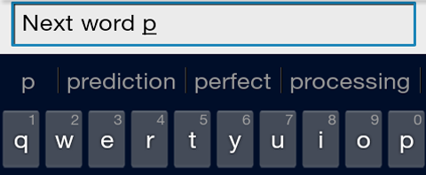

# Introduction

Around the world, people are spending an increasing amount of time on their mobile devices for email, social networking, banking and a whole range of other activities. But typing on mobile devices can be a serious pain. When someone types:

*I went to the*

the keyboard presents three options for what the next word might be. For example, the three words might be *gym, store, restaurant*.

This project report is part of a larger project to design a text prediction system that could be run efficiently on a mobile device.

Here we consider only an initial analysis a large corpus of text documents, involving the cleaning and analysis of text data, leading up to the building and sampling from a predictive text model in future project work.

# Ultra Brief NLP Oveview

Natural Language Processing (NLP) combines knowledge from linguistics, computer science, statistics and machine learning disciplines, and concerns the interactions between computers and humans (see Wikipedia https://en.wikipedia.org/wiki/Natural_language_processing). NLP covers a wide range of uses from classification of documents, sentiment analysis, chatbots, and text prediction, among many other.

Some basic and common steps or techniques used in NLP applications are:-

- Sentence detection - breaking up text data into separate sentences.
- Tokenization - splitting sentences in parts, typically words.
- Chunking - Deriving logical concepts from the tagged tokens within a sentence.
- Part-of-speech (POS) tagging - Tokens (words) are assigned as a noun, verb, adjective, adverb etc.
- Entity Identification/Extraction - people, locations, events, etc are extracted from the text chunks.

In our application of text prediction, issues we might face in the analysis and processing of the data are the use of colloquial or slang language - especially from social media sources - and incorrect punctuation, as well as poor spelling.

# N-Gram Text Prediction

Our text prediction model is based on using a very large amount of “example” text mined from various online sources, from which we can identify common patterns or phrases that occur. These patterns or phrases here consist of groups of 1,2 or 3 words (called **“n-grams”**) that frequently appear together.

This is the basis of our prediction - the user types, we search for short phrases that contain the last few words inputted by the user plus a further word or two, and we present the most “likely” next three choices.

## File Summaries

For this project we are using a set of text documents, or *corpora*, provided by HC Corpora (http://www.corpora.heliohost.org). A readme file here http://www.corpora.heliohost.org/aboutcorpus.html provides details about these corpora.

The Coursera dataset (CAUTION: > 500MB!!) analyzed for this report is available here: https://d396qusza40orc.cloudfront.net/dsscapstone/dataset/Coursera-SwiftKey.zip.

This set of files have had meta tags about source, date, time, etc. removed, so are purely lines of text that can be read in using readLines() for example. The files in this corpora have been filtered for language, but they may still contain some foreign language words.

**NOTE: This data set included files in American-English, Russian, Finnish and German. Only the American-English language files are considered in this project.**

### Line and word counts

There are three input files from these sources:

- News - factual, as well as plain-word text these contain many numbers, prices, costs, email addresses, URLs
- Blogs - language that is more personal, opinion and personal experience with less “clutter”
- Twitter - short collections of a handful of sentences, containing a large proportion of slang

A summary of the raw files sizes, the object size in R, and the word and line counts is given below:

[output not shown]

NOTE: The line and word counts were found using Notepad++.

These files are very large. Given that we are targeting to run our prediction app on a mobile platform, I will aim to randomly sample lines totaling 2MB from each of the three files, and combine into one corpus of about 6MB for the remaining analysis. 6MB should be a reasonable size to generate our ngram frequency dictionaries from, and these can be further reduced by dropping very low frequency entries.

## Initial Data Preparation

We need to sample a smaller set from these three files, combine to one, and then process by removing punctuation, foul words, etc, before we can derive n-gram frequency counts for this input text.

## Combine and Sample

First, we’ll randomly sample 2MB from each input file, and combine them.

To give a flavour of the content, here are samples of each file:

### Samples

#### News

```
## [1] "Pour off the fat from the roasting pan, leaving the juices behind. Put the roasting pan on top of the stove over medium-high heat and add the remaining wine and 1/2 cup water, scraping up any clinging bits from the pan, and reduce to about 3/4 cup. Strain through a chinoise or a wire mesh si…
## [2] "Alternatively, this avoidable risk suggests a standard of laxity in the midst of a campaign tour masquerading as a policy parade. Revealingly, the president's target audience consists of unwitting metaphors for the state of the union -- unemployed and deep in debt."
## [3] "On one side is the Department of Buildings, which has proposed regulations that would allow anyone who qualifies for a specific crane license in selected large cities to work in New York after meeting experience requirements and undergoing 40 hours of classroom training."
```

#### Blogs

```
## [1] "I finally got around to washing the headband strap in my hard hat, for the first time. It was rank. And you may be thinking, Havent you been in AmeriCorps since October? The answer is yes. Thats about 7 months of ick built up. Ive learned that part of this program is coming to terms with bei…
## [2] "You laughing yet?"
## [3] "We have a gigantic porch. It is fairly well protected from the weather and it is a whole lot of fun to decorate! It was dressed to the nines for the holidays. Once that got all put away, it was time for a simpler look. I had lots of red pieces before. Here it is looking quite patriotic. Whit…
```

#### Twitter

```
## [1] "Hiding from 's sister and her friends under a cabinet in the bathroom<333"
## [2] "Gamecocks up 1-0 over Citadel after 1st. Jordan Montgomery pitching for Carolina."
## [3] "You need a Purple-induced blackout to recover, methinks."
```

As you can see, the raw text contain emoticons, numbers, unicode, slang, and so on.

### Remove punctuation

We will not try to perform any spelling correction or detection of foreign words, but will simply remove punctuation like parentheses, colons, semicolons, whilst leaving apostrophes and hyphens in place, as many words are hyphenated as would lose meaning or context if we strip out all hyphens.

### Convert to lower case

We will also ignore all non-alphabetic tokens like prices, urls, emails etc, and convert all text to lower case. This does mean our predictions will all be lower case, so proper nouns like people’s names and place names would be in lower case if predicted.

### Remove foul words

We could write our own list of foul words to remove, but we’d have to consider all stems and forms of each word. Easier it to use an existing list, which can be found online e.g. http://www.bannedwordlist.com/lists/swearWords.txt which contains 77 very common uncouth, crude or rude words on which we don’t want to make predictions.

# Exploratory Analysis

The first thing to do is find the most common words (or “1-grams”, in our n-gram framing for this problem). Words that occur very rarely are unlikely to be useful, and these are likely to be a large fraction of our data.

We want to know how many unique words account for what proportion of our sample corpus, i.e. the language coverage.

## Single words (1-gram)

```
## Sample corpus contains 740159 total words
```

```
## Sample corpus contains 53569 unique words
```

In our sample corpus we have over 50,000 unique “words”, from nearly 3/4 of a million total words.

Let’s see how many words cover 50% and 90% of the total:

```
## To cover 50% of all words, you need 156 words
```

```
## To cover 90% of all words, you need 8666 words
```

So there may be some memory and time saving to reduce the dictionary of words in our prediction down to the order of 10,000 from the full 50,000 in our sample corpus.

## 2-grams & 3-grams

Again, for 2-grams and 3-grams, we will probably not find it useful to keep those which occur only a very few times in our corpus, instead focusing the prediction on those that occur more often. This will allow us to reduce memory and compute time.

Below are the top ten most frequent n-grams for n-grams of lengths 1,2 and 3.

### Most Common N-Grams

#### 1-gram

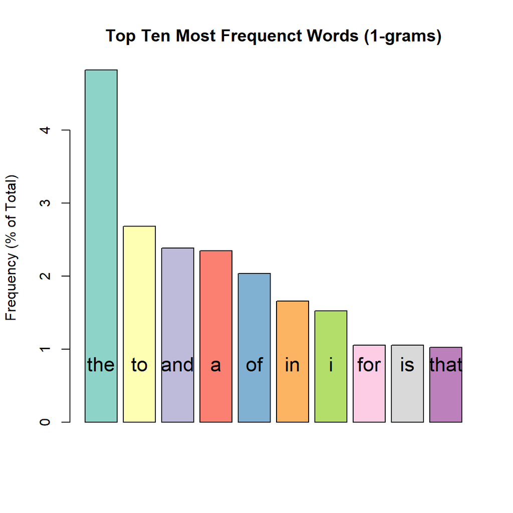

#### 2-gram

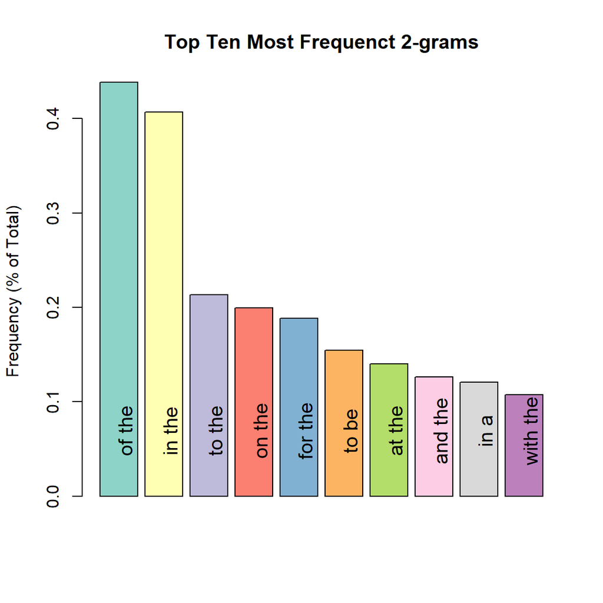

#### 3-gram

[figure not shown]

### Language Coverage

Below is a graph for each n-gram size showing the percentage of total coverage versus the percentage of n-grams used, using the most frequent n-grams first (i.e. sorted in descending frequency as used in this report).

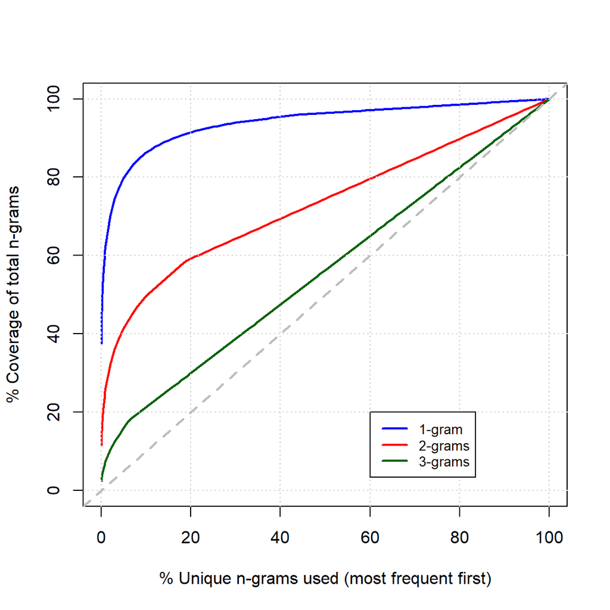

We see that for individual words (1-grams), we can cover 90% of our sample corpus with only the top 20% most frequent words.

# Next Steps

This work covers only the very early stages of the predictive text app development. We have looked at text import, processing and initial study in terms of n-gram frequencies. There is a great deal of work and improvement still to do!

## Use “tm” package

Instead of processing text using regular expressions “by hand” as used in this report, in the forthcoming project work, I’ll use packages for text mining, like “tm” to more easily and powerfully process text.

## Create Predictive Model

The next major steps are to implement a predictive algorithm based on reduced n-gram tables based on those generated in this report.

## Code for this report

The code used to generate this report is available on github here:

https://github.com/threefeetdeep/CapstoneProject/blob/master/milestone_report.Rmd

(NOTE: use “open in new tab” if R-pubs refuses to connect)